# gdv - Fundamentals of data visualization

Yvo Keller

# Introduction

This report will cover my learning’s as part of the fundamentals of data visualization, based on the data from the “Cross-Selling in Banking” challenge I completed two semester back. I will take this opportunity to look at plotting from the data visualization standpoint this time and improve on the results based on my newly obtained knowledge.

```r
load("gdv.RData")
library(tidyverse)
library(lubridate)
library(scales)
library(sf)
library(RCzechia)
library(ggsn)
```

# LO 1: Visualization basics, chart types

In this first chapter, I will be looking at…

- different types of visualizations
- factors that play a role in deciding which visualization is a fit for what data
  - considerations of visual variables
  - perceptual theories
  - empirical evidence
  - target group characteristics

## Density Plot

When we want to better understand the characteristics of continuous data, a *density plot* can be really helpful. This plot looks at the age distribution of the bank clients, by gender. It shows us the share of a given age (x-axis) and gender in the customer base.

I purposely made some adjustments to the standard plot, to align with what the age stands for logically.

- There are no customers younger than 10 years. However, every person was once younger, and I want to make clear for everybody looking at the plot that there are no customers under the age of 10. Therefore, the x-axis is fixed to start at 0.
- The standard labels on x would only show the age at 4 positions, which makes it difficult to read. To fix that, I changed the scale to be shown in an interval of 10 years.

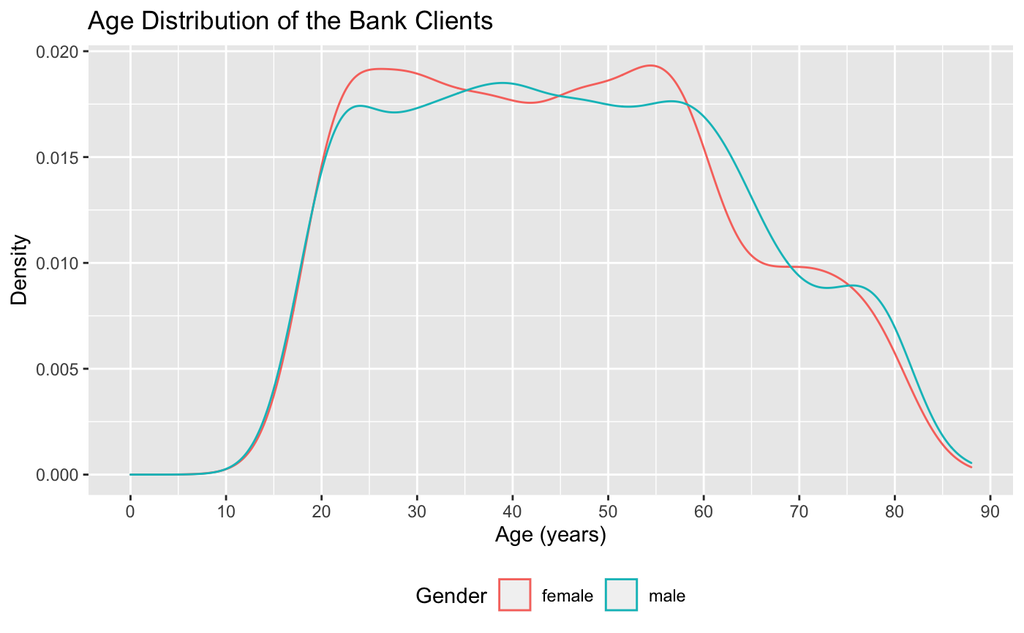

```r
ggplot(df_client_prep, aes(x = age, color = gender)) +
  geom_density() +
  labs(title = "Age Distribution of the Bank Clients", x = "Age (years)", y = "Density", color = "Gender") +
  theme(legend.position = "bottom") +
  scale_x_continuous(breaks = scales::pretty_breaks(n = 10)) +
  expand_limits(x = 0)
```

## Violin Plot

Another way of showing distributions is a violin plot. That allows a better distinction of the distributions using a discrete value. Instead of lines on one plot, we can see the distributions side by side. I found this a really nice way of finding patterns in the data. Using comparisons, taking some time to look at it, differences stand out really well to the viewers eye.

In this specific case, we can see the correlation between loan status and loan size nicely. The colors used are also a good match to the meaning behind the status. Red is bad, green is good, pink is bad so far, and yellow-green stands for good so far.

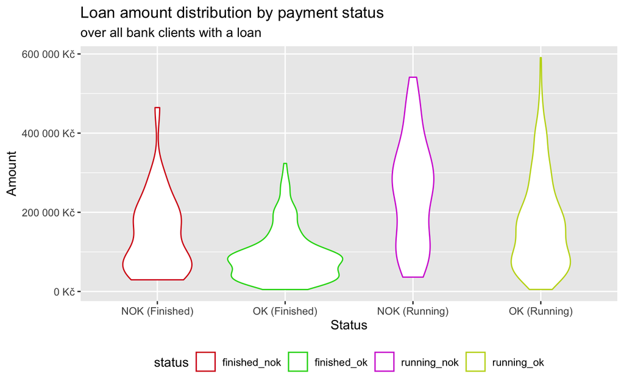

```r
ggplot(df_loan_prep, aes(x = status, y = amount, color = status)) +
  geom_violin() +
  scale_y_continuous(labels = label_number(suffix = " Kč", scale = 1e+0)) +
  scale_x_discrete(labels = c("NOK (Finished)", "OK (Finished)", "NOK (Running)", "OK (Running)")) +
  labs(title = "Loan amount distribution by payment status", subtitle = "over all bank clients with a loan", x = "Status", y = "Amount") +
  theme(legend.position = "bottom") +
  scale_color_manual(values=loan_status_colors)
```

## Scatter Plot

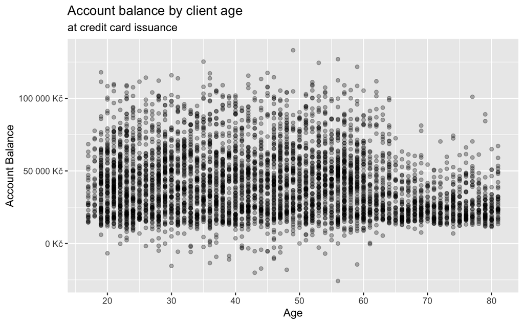

```r
ggplot(df_car, aes(x = client.age, y = eng.balance_at_card_issuance)) +
  geom_point(alpha = 0.3) +
  scale_x_continuous(breaks = scales::pretty_breaks(n = 10)) +
  scale_y_continuous(labels = label_number(suffix = " Kč", scale = 1e+0)) +
  labs(title = "Account balance by client age", subtitle = "at credit card issuance", x = "Age", y = "Account Balance")
```

```r
NA
```

# LO2

## Bubble Chart

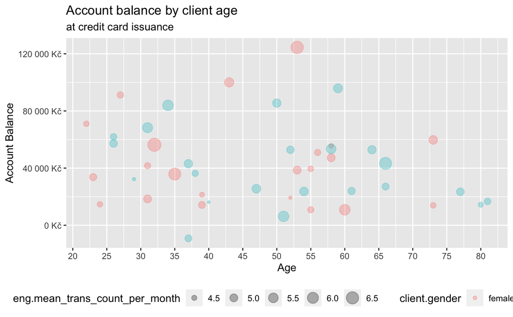

```r
df_car_sample <- slice_sample(df_car, prop = 0.01)

ggplot(df_car_sample, aes(x = client.age, y = eng.balance_at_card_issuance)) +
  geom_point(aes(color = client.gender, size = eng.mean_trans_count_per_month), alpha = 0.3) +
  scale_x_continuous(breaks = scales::pretty_breaks(n = 10)) +
  scale_y_continuous(labels = label_number(suffix = " Kč", scale = 1e+0)) +
  theme(legend.position = "bottom") +
  labs(title = "Account balance by client age", subtitle = "at credit card issuance", x = "Age", y = "Account Balance")
```

```r
df_temp <- df_client_prep %>%
  inner_join(df_district_prep, by = c("district_id_client" = "district_id")) %>%
  count(region, gender)
df_temp
```

| region | gender | n |
| --- | --- | --- |
| central Bohemia | female | 336 |
| central Bohemia | male | 328 |
| east Bohemia | female | 318 |
| east Bohemia | male | 342 |
| north Bohemia | female | 281 |
| north Bohemia | male | 280 |
| north Moravia | female | 437 |
| north Moravia | male | 483 |
| Prague | female | 324 |
| Prague | male | 339 |

[output cut: 6 more lines]

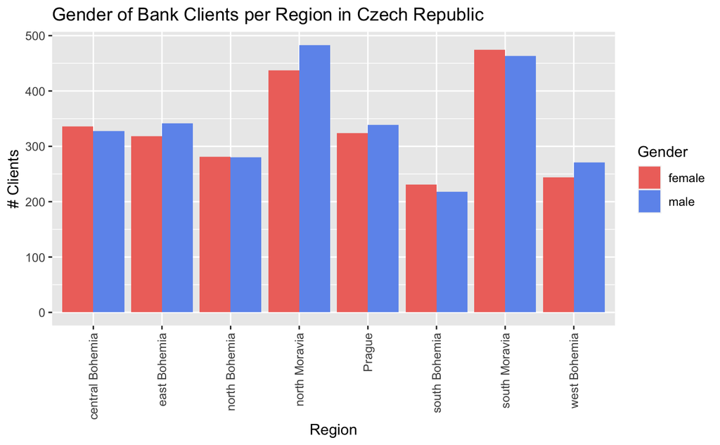

```r
df_temp <- df_client_prep %>%
  inner_join(df_district_prep, by = c("district_id_client" = "district_id"))

ggplot(df_temp, aes(x = region, fill = gender)) +
  geom_bar(position="dodge") +
  scale_fill_manual(values=c("#EF736B", "#6E98ED")) +
  labs(title = "Gender of Bank Clients per Region in Czech Republic", x = "Region", y = "# Clients", fill = "Gender") +
  theme(axis.text.x = element_text(angle = 90, vjust = 0.5, hjust=1), legend.position = "right")
```

```r
rm(df_temp)
```

## Map

```r
borders <- RCzechia::republika("low")
counties <- RCzechia::okresy("low") %>%
  rename(district_name = NAZ_LAU1) %>%
  arrange(district_name)

district_data <- df_district_prep %>%
  mutate(
    district_name = recode(district_name, "Hl.m. Praha"="Praha"),
    district_name = as.character(district_name)
  ) %>%
  arrange(district_name)

district_data$district_name = counties$district_name

counties_with_data <- counties %>%
  inner_join(district_data, by="district_name")
```

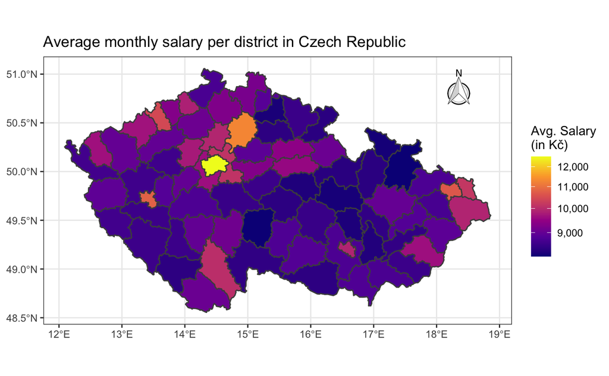

```r
# report results
ggplot() +
  geom_sf(data=borders, color="gray25") +
  geom_sf(data=counties_with_data, color="gray30", aes(fill = avg_salary)) +
  north(data=counties_with_data, scale=0.15, location = "topright") +
  scale_fill_viridis_c(option = "plasma", trans = "log", labels = scales::comma) +
  labs(title = "Average monthly salary per district in Czech Republic", fill = "Avg. Salary\n(in Kč)") +
  theme_bw()
```

# LO3

```r
df_temp <- df_order_prep %>%
  rename(disp.account_id = account_id) %>%
  inner_join(df_car, by="disp.account_id") %>%
  group_by(card.type, payment_category) %>%
  count(payment_category) %>%
  replace_na(list(card.type = "no card", y = "missing"))

df_temp
```

| card.type | payment_category | n |
| --- | --- | --- |
| classic | household | 460 |
| classic | insurance | 78 |
| classic | leasing | 72 |
| classic | loan | 137 |
| classic | missing | 220 |
| gold | household | 60 |
| gold | insurance | 10 |
| gold | leasing | 8 |
| gold | loan | 16 |
| gold | missing | 30 |

[output cut: 10 more lines]

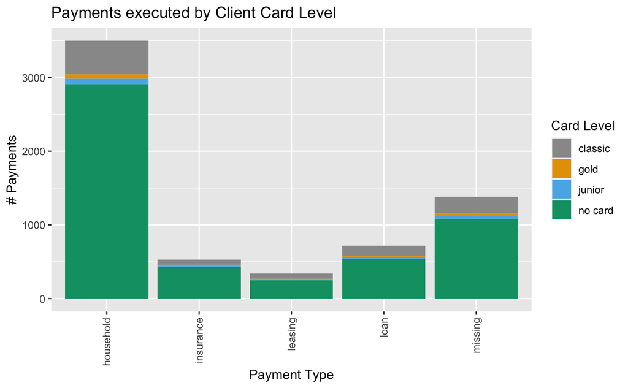

```r
cb_palette <- c("#999999", "#E69F00", "#56B4E9", "#009E73", "#F0E442", "#0072B2", "#D55E00", "#CC79A7")

df_temp <- df_order_prep %>%
  rename(disp.account_id = account_id) %>%
  inner_join(df_car, by="disp.account_id") %>%
  group_by(card.type, payment_category) %>%
  count(payment_category) %>%
  replace_na(list(card.type = "no card", y = "missing"))

ggplot(df_temp, aes(x = payment_category, y = n, fill = card.type)) +
  geom_col() +
  scale_fill_manual(values=cb_palette) +
  labs(title = "Payments executed by Client Card Level", x = "Payment Type", y = "# Payments", fill = "Card Level") +
  theme(axis.text.x = element_text(angle = 90, vjust = 0.5, hjust=1), legend.position = "right")
```

```r
rm(df_temp)
```

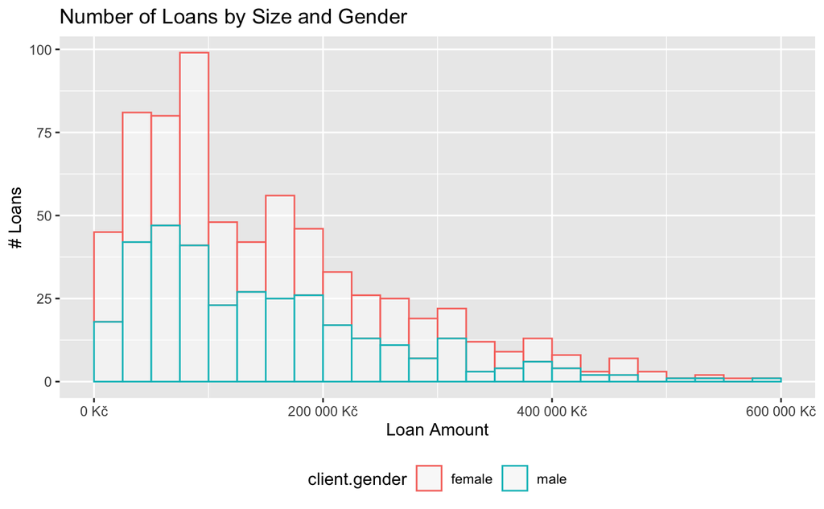

```r
ggplot(df_car, aes(x=loan.amount, color = client.gender)) +
  geom_histogram(binwidth=25000, boundary=0, alpha=0.5, fill="white") +
  scale_x_continuous(labels = label_number(suffix = " Kč", scale = 1e+0)) +
  labs(title = "Number of Loans by Size and Gender", x = "Loan Amount", y = "# Loans", fill = "Gender") +
  theme(legend.position = "bottom")
```

# LO4

## Balance Development

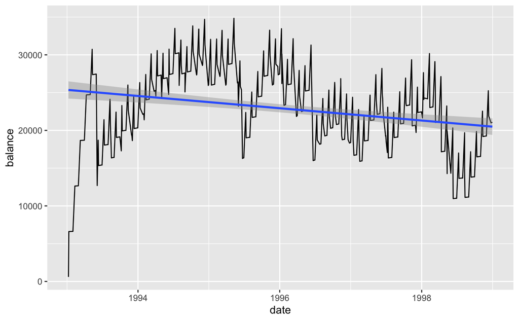

```r
df_temp <- df_trans_prep %>%
  filter(account_id == 3592)

df_temp$year = year(df_temp$date)

ggplot(df_temp, aes(x = date, y = balance)) +
  geom_line() +
  stat_smooth(method='lm')
```

## Relation between average income and loan size

### Data Prep

```r
df_temp <- df_car %>%
  select(loan.amount, credit_check_avg_income, client.gender, loan.status, card.has_card) %>%
  drop_na() %>%
  filter(loan.status == "finished_ok" | loan.status == "running_ok") %>%
  mutate(card.info = case_when(
    card.has_card == TRUE ~ "Credit Card",
    card.has_card == FALSE ~ "No Credit Card"
  )) %>%
  mutate(loan.status = recode(loan.status, "running_ok" = "Loan Running OK", "finished_ok" = "Loan Finished OK"))
df_temp
```

| loan.amount | credit_check_avg_income | client.gender | loan.status | card.has_card | card.info |
| --- | --- | --- | --- | --- | --- |
| 80952 | 20236 | male | Loan Finished OK | FALSE | No Credit Card |
| 165960 | 41490 | female | Loan Finished OK | FALSE | No Credit Card |
| 102876 | 17928 | male | Loan Finished OK | TRUE | Credit Card |
| 162576 | 23438 | male | Loan Running OK | TRUE | Credit Card |
| 104808 | 17313 | male | Loan Finished OK | FALSE | No Credit Card |
| 112752 | 15405 | female | Loan Running OK | TRUE | Credit Card |
| 66840 | 36897 | female | Loan Running OK | FALSE | No Credit Card |
| 468060 | 46807 | female | Loan Running OK | TRUE | Credit Card |
| 100980 | 13948 | male | Loan Running OK | FALSE | No Credit Card |
| 91152 | 22789 | male | Loan Finished OK | TRUE | Credit Card |

[output cut: 284 more lines]

### Aesthetics

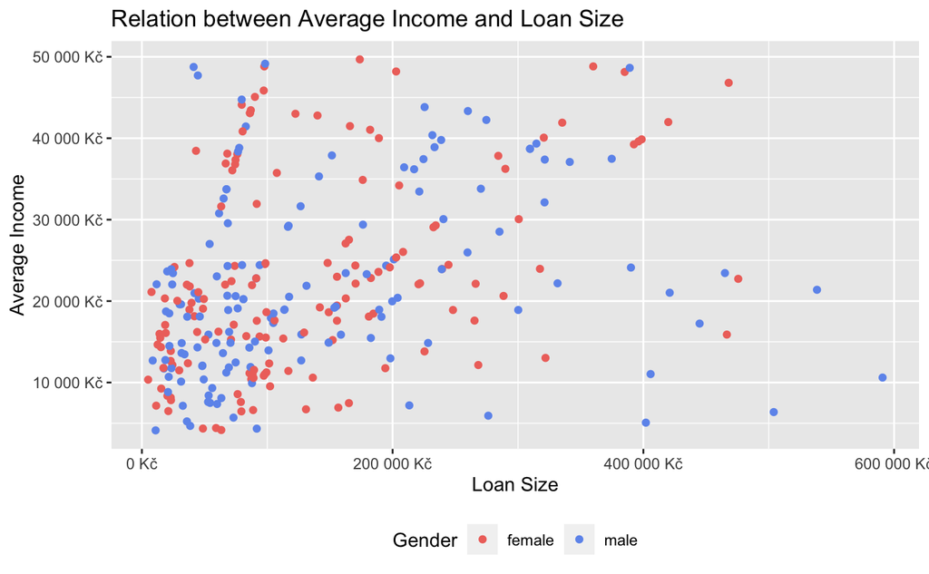

```r
ggplot(df_temp, aes(x=loan.amount, y=credit_check_avg_income, color = client.gender)) +
  geom_point() +
  scale_x_continuous(labels = label_number(suffix = " Kč", scale = 1e+0)) +
  scale_y_continuous(labels = label_number(suffix = " Kč", scale = 1e+0)) +
  scale_colour_manual(values=c("#EF736B", "#6E98ED")) +
  labs(title = "Relation between Average Income and Loan Size", x = "Loan Size", y = "Average Income", color = "Gender") +
  theme(legend.position = "bottom")
```

### Statistical measure

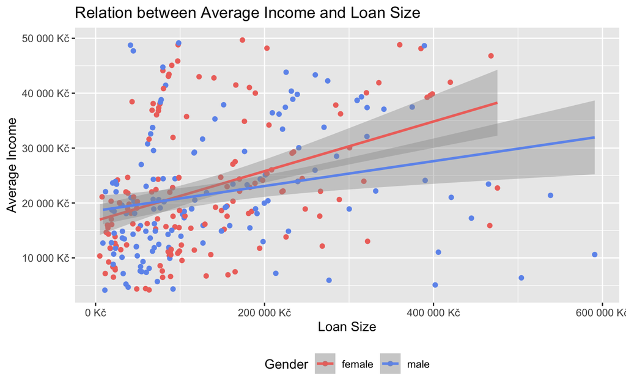

```r
ggplot(df_temp, aes(x=loan.amount, y=credit_check_avg_income, color = client.gender)) +
  geom_point() +
  scale_x_continuous(labels = label_number(suffix = " Kč", scale = 1e+0)) +
  scale_y_continuous(labels = label_number(suffix = " Kč", scale = 1e+0)) +
  scale_colour_manual(values=c("#EF736B", "#6E98ED")) +
  labs(title = "Relation between Average Income and Loan Size", x = "Loan Size", y = "Average Income", color = "Gender") +
  theme(legend.position = "bottom") +
  stat_smooth(method='lm')
```

### Facet

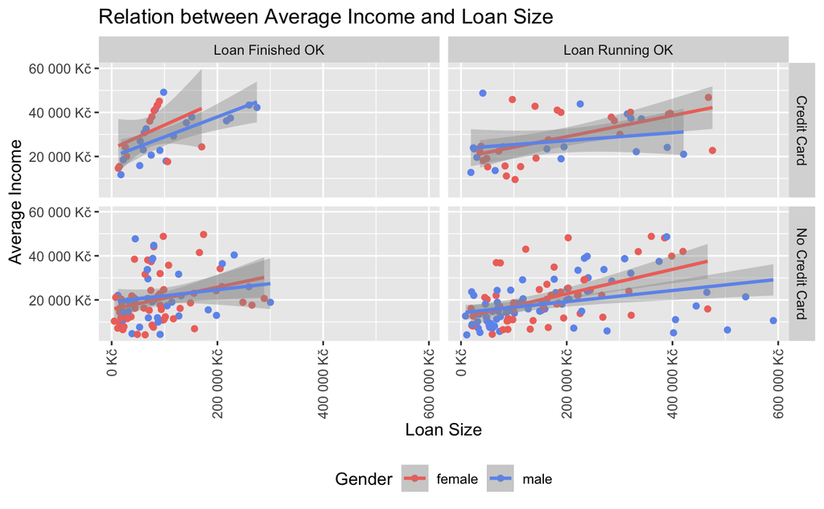

```r
ggplot(df_temp, aes(x=loan.amount, y=credit_check_avg_income, color = client.gender)) +
  geom_point() +
  scale_x_continuous(labels = label_number(suffix = " Kč", scale = 1e+0)) +
  scale_y_continuous(labels = label_number(suffix = " Kč", scale = 1e+0)) +
  scale_colour_manual(values=c("#EF736B", "#6E98ED")) +
  stat_smooth(method='lm') +
  labs(title = "Relation between Average Income and Loan Size", x = "Loan Size", y = "Average Income", color = "Gender") +
  facet_grid(vars(card.info), vars(loan.status)) +
  theme(axis.text.x = element_text(angle = 90, vjust = 0.5, hjust=1), legend.position = "bottom")
```

# LO5

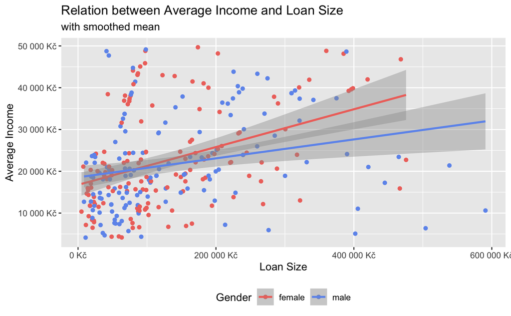

```r
ggplot(df_temp, aes(x=loan.amount, y=credit_check_avg_income, color = client.gender)) +
  geom_point() +
  scale_x_continuous(labels = label_number(suffix = " Kč", scale = 1e+0)) +
  scale_y_continuous(labels = label_number(suffix = " Kč", scale = 1e+0)) +
  scale_colour_manual(values=c("#EF736B", "#6E98ED")) +
  labs(title = "Relation between Average Income and Loan Size", subtitle = "with smoothed mean", x = "Loan Size", y = "Average Income", color = "Gender") +
  theme(legend.position = "bottom") +
  stat_smooth(method='lm')
```